# DeepC Tutorial Format HiC Data

This tutorial demonstrates how to format HiC data for deepC training. The tutorial walks through formating a single chromosome. In practice we prepare each chromosome separately and concatinate all chromosome files in the end to a single file for training.

### Global Set up

Load packages and source custom functions for deepC and general HiC processing and visualization.

```r
library(tidyverse)
library(cowplot)
theme_set(theme_cowplot())
library(RColorBrewer)

source("./deepC/helper_for_preprocessing_and_analysis/functions_for_HiC.R")
source("./deepC/helper_for_preprocessing_and_analysis/functions_for_deepC.R")
```

Set global options, specifiying bin size and bp context of the model.

```r
sample <- "GM12878"
bin.size <- 5000

window.size <- 1000000 + bin.size  # bp_context
# how many HiC skeleton bins have been used (10 for all published models)
interaction.value.bins <- 10
# number of predictions bins (also called number of classes later). Refers to number
# of bins in the vertial interaction pole
# depends on the bin.size and bp_context selected:
# 201 for 5kb models, 101 for 10kb models
prediction.bins <- window.size/bin.size

# link to chromosome sizes file (ucsc style)
genome.sizes <- read.table('hg19_chrom_sizes.txt')
```

```bash
head hg19_chrom_sizes.txt
```

```
## chr1 249250621
## chr2 243199373
## chr3 198022430
## chr4 191154276
## chr5 180915260
## chr6 171115067
## chr7 159138663
## chrX 155270560
## chr8 146364022
## chr9 141213431
```

### Read in HiC Data

Set the chromosome and read in the Hi-C data. The skeleton transformation is done chromosome wise and for memory friendliness we recommend doing this separate for each chromosome and concatinating the output into a single file.

We support two Hi-C data formats, both are sparse matrix formats:

1. HiC-Pro style format comprising a sparse matrix with tab separated: *bin_id1 bin_id2 interaction_value* and a second bed-like file that lists the genomic coordinates of the bin_ids *chr start end bin_id*
2. A sparse contact matrix with the genomic coordinates as identifiers e.g.

```bash
head gm12878_primary_chr17_5kb.contacts.KRnorm.matrix
```

```
## 0    0   1092.39634212411
## 0    5000    272.056324049362
## 5000 5000    707.645865108206
## 0    10000   113.901873171691
## 5000 10000   202.53587051085
## 10000    10000   817.905220550323
## 0    15000   104.228608910218
## 5000 15000   120.956194934016
## 10000    15000   261.414278868473
## 15000    15000   1263.85448972055
```

This matrix has norm factos applied thats why the contact values are not discrete.

Both formats list the left most base of a bin sized interval as identifier for the bin position.

We first read in the Hi-C data, inspect the object and create a binned genome template for filling.

```r
# Set chromosome name
chrom <- "chr17"

# get the respective chromosome size
chrom.size <- as.numeric(genome.sizes[genome.sizes[,1] == chrom,2])

# to read in a HiC matrix with the format coord_bin1 coord_bin2 interaction_value
# (e.g. as Rao et al. downloads)
# provide the matrix file, the chromosome and bin.size arguments
# if the format is like HiC-Pro (bin1_id bin2_id interaction_value) with a separate
# bed-like coordinate file
# provide the coordinate file in the "coords=" argument of the Import function
matrix.norm.loc <- "gm12878_primary_chr17_5kb.contacts.KRnorm.matrix"

hic <- ImportHicproMatrix(matrix.norm.loc, chr=chrom, bin.size=bin.size)

# remove all interactions that are more then bp_context apart
hic <- trimHicRange(hic, range = window.size + bin.size)

# The HiC data is stored in a structures list storing the bin size start position
# and stat id as well as the coordinates with bin associations
str(hic)
```

```
## List of 5
##  $ matrix.df: tibble [2,563,166 × 5] (S3: tbl_df/tbl/data.frame)
##   ..$ y    : num [1:2563166] 2500 2500 7500 2500 7500 12500 2500 7500 12500 17500 ...
##   ..$ x    : num [1:2563166] 2500 7500 7500 12500 12500 12500 17500 17500 17500 17500 ...
##   ..$ value: num [1:2563166] 1092 272 708 114 203 ...
##   ..$ y.id : num [1:2563166] 0 0 1 0 1 2 0 1 2 3 ...
##   ..$ x.id : num [1:2563166] 0 1 1 2 2 2 3 3 3 3 ...
##  $ coords   : tibble [15,398 × 5] (S3: tbl_df/tbl/data.frame)
##   ..$ chr   : Factor w/ 1 level "chr17": 1 1 1 1 1 1 1 1 1 1 ...
##   ..$ start : num [1:15398] 0 5000 10000 15000 20000 25000 30000 35000 40000 45000 ...
##   ..$ end   : num [1:15398] 5000 10000 15000 20000 25000 30000 35000 40000 45000 50000 ...
##   ..$ id    : num [1:15398] 0 1 2 3 4 5 6 7 8 9 ...
##   ..$ center: num [1:15398] 2500 7500 12500 17500 22500 27500 32500 37500 42500 47500 ...
##  $ bin.size : num 5000
##  $ start.pos: num 2500
##  $ start.id : num 0
```

```r
#  and the actual contact matrix under $marix.df
hic$matrix.df
```

```
## # A tibble: 2,563,166 × 5
##        y     x value  y.id  x.id
##    <dbl> <dbl> <dbl> <dbl> <dbl>
##  1  2500  2500 1092.     0     0
##  2  2500  7500  272.     0     1
##  3  7500  7500  708.     1     1
##  4  2500 12500  114.     0     2
##  5  7500 12500  203.     1     2
##  6 12500 12500  818.     2     2
##  7  2500 17500  104.     0     3
##  8  7500 17500  121.     1     3
##  9 12500 17500  261.     2     3
## 10 17500 17500 1264.     3     3
## # … with 2,563,156 more rows
```

```r
# check the first covered position in the HiC data
start.pos <- hic$start.pos - bin.size/2

# to map the hic data into consistent bins for deepC training, prediction and
# plotting we create get a binned genome template this requires bedtools
# to be installed as the R function calls bedtools in the background in bash
binned.genome <- getBinnedChrom(chr=chrom, start=start.pos, end=chrom.size, window=window.size, step=bin.size)
binned.genome <- as_tibble(binned.genome)
names(binned.genome) <- c("chr", "start", "end")
# filter out ibcombplete megabase bins
binned.genome <- binned.genome %>%
  mutate(width = end - start) %>%
  filter(width == window.size) %>%
  select(-width)

# quick look at the binned genome
binned.genome
```

```
## # A tibble: 16,081 × 3
##    chr   start     end
##    <chr> <dbl>   <dbl>
##  1 chr17     0 1005000
##  2 chr17  5000 1010000
##  3 chr17 10000 1015000
##  4 chr17 15000 1020000
##  5 chr17 20000 1025000
##  6 chr17 25000 1030000
##  7 chr17 30000 1035000
##  8 chr17 35000 1040000
##  9 chr17 40000 1045000
## 10 chr17 45000 1050000
## # … with 16,071 more rows
```

### Convert to deepC Format

Next we convert the Hi-C interactions first into deepC format with a vvertical zig-zag pole associated with the center of each bp_context sized sequence window. Second we transform the interaction values into the Hi-C skeleton by applying the pyramid shaped percentile binning. The data are percentile normalized into unequal bins from low to high values in the following scheme: 2x20% 4x10% 4x5% percentiles.

```r
# Convert Hi-C interaction matrix into genomic windows of bp_context size with the vertical
# "zig-zag" pole of associated chromatin interactions
# Get ZigZiag Pole ZickZack Pole of interactions per window
#    /
#    \
#    /
#    \
#    |
# """""""
#     | 4 |     | 4 |
#       | 2 || 2 |
# | 5 | 3 | 1 | 3 | 5 |
# uses helper perl scripts from the repository
# There is a memory friendly version of the function which relies on two perl helper scripts
# but takes a tad longer
tdf <- getZigZagWindowInteractionsPerl(hic,
         binned.genome,
         window.size,
         bin.size,
         query.pl= "./deepC/helper_for_preprocessing_and_analysis/match_query_table.pl")
```

```
## [1] "saved temp_hic_file"
## [1] "saved temp_query_file"
## [1] "matching ..."
```

```r
# tdf <- getZigZagWindowInteractionsPerlMemoryFriendlyFullPerl(hic,
  # binned.genome,
  # window.size,
  # bin.size,
  # prepare.pl = "./deepC/current_version/......prepare_query_table.pl", #todo
  # query.pl= "./deepC/helper_for_preprocessing_and_analysis/match_query_table.pl")

# Impute zero values in interaction matrix with Median of a 5x5 neighborhood
# padd with median of respective interaction distance for calculating
# the median on edge cases

# first add median column
tdf$median.value <- apply(tdf, 1, function(x){
  m <- median(as.numeric(x[c(4:length(x))]))
  return(m)
})

# filter out genomic windows with median 0 interaction values
fdf <- tdf[tdf$median.value > 0,]

# impute zeros with 5x5 median value
idf <- medianImputeZerosDataFrame(fdf, k=5)
idf <- idf[,-ncol(idf)]  #remove padded

# convert to tibble
idf <- as_tibble(idf)

# pyramid percentile binning
bdf <- pyramidBin(idf)
# inspect
bdf
```

```
## # A tibble: 14,578 × 204
##    chr   start     end   `1`   `2`   `3`   `4`   `5`   `6`   `7`   `8`   `9`
##    <chr> <dbl>   <dbl> <dbl> <dbl> <dbl> <dbl> <dbl> <dbl> <dbl> <dbl> <dbl>
##  1 chr17     0 1005000     1     1     9     6     1     9     6     9     7
##  2 chr17  5000 1010000     9     1     1     2     1     5     9     2     3
##  3 chr17 10000 1015000     9    10     1     1     1    10     9    10     8
##  4 chr17 15000 1020000    10     1     2     6     8     2     3     5     1
##  5 chr17 20000 1025000    10     7     7     8     6     7     8     5     5
##  6 chr17 25000 1030000     8     2     6     9     2     7     2     8     5
##  7 chr17 30000 1035000     7     5     8     1     2     3     3     5     4
##  8 chr17 35000 1040000    10    10     6     9     5     1     4     1     2
##  9 chr17 40000 1045000     6     1     4     3     8     6     6     2     6
## 10 chr17 45000 1050000    10    10     7     5     3     4     8     6     5
## # … with 14,568 more rows, and 192 more variables: 10 <dbl>, 11 <dbl>,
## #   12 <dbl>, 13 <dbl>, 14 <dbl>, 15 <dbl>, 16 <dbl>, 17 <dbl>, 18 <dbl>,
## #   19 <dbl>, 20 <dbl>, 21 <dbl>, 22 <dbl>, 23 <dbl>, 24 <dbl>, 25 <dbl>,
## #   26 <dbl>, 27 <dbl>, 28 <dbl>, 29 <dbl>, 30 <dbl>, 31 <dbl>, 32 <dbl>,
## #   33 <dbl>, 34 <dbl>, 35 <dbl>, 36 <dbl>, 37 <dbl>, 38 <dbl>, 39 <dbl>,
## #   40 <dbl>, 41 <dbl>, 42 <dbl>, 43 <dbl>, 44 <dbl>, 45 <dbl>, 46 <dbl>,
## #   47 <dbl>, 48 <dbl>, 49 <dbl>, 50 <dbl>, 51 <dbl>, 52 <dbl>, 53 <dbl>, …
```

### Example Skeleton Plot

Now we plot a chunk of the skeleton for checking.

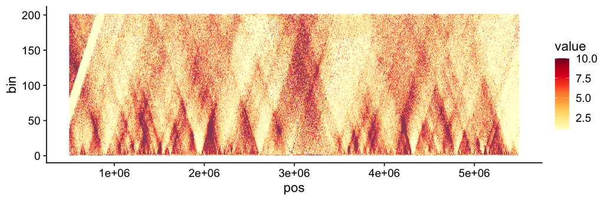

```r
  # Create example plot
  # Make a position column, gather and tranform to numeric interactions bins
  # take first 1000 entries
  pdf <- head(bdf, n=1000) %>%
    mutate(pos = start+((end-start)/2)) %>%
    gather(bin, value, -chr, -start, -end, -pos, factor_key = T) %>%  # gather
    mutate(bin = as.numeric(bin)) %>%
    mutate(pos = if_else(bin %% 2 == 0, pos - bin.size/2, pos))  # adjust positions for
    # zig-zag layout

  # # Plot Coverage of interaction windows
  tpdf <- triangularize(pdf, bin = bin.size)

  p <- ggplot(tpdf, aes(y=bin, x=pos, fill=value, group = polyid)) +
    geom_polygon() +
    scale_fill_gradientn(colours = brewer.pal(9, 'YlOrRd'))

  plot(p)
```

### Save

Now we just need to store the data in txt format.

```r
  # collate to single comma separated column
  bdf$class <- bdf %>%
    select(-chr, -start, -end) %>%
    unite(col = class, sep = ",") %>%
    pull()

  # and trim output
  bdf <- bdf %>% select(chr, start, end, class)

  # inspect
  bdf
```

```
## # A tibble: 14,578 × 4
##    chr   start     end class
##    <chr> <dbl>   <dbl> <chr>
##  1 chr17     0 1005000 1,1,9,6,1,9,6,9,7,5,9,5,5,6,4,10,9,4,4,6,7,7,8,10,6,9,9,…
##  2 chr17  5000 1010000 9,1,1,2,1,5,9,2,3,6,9,4,9,6,1,10,6,6,6,7,9,6,5,4,10,10,9…
##  3 chr17 10000 1015000 9,10,1,1,1,10,9,10,8,10,4,7,3,7,4,5,3,8,10,5,9,7,10,8,5,…
##  4 chr17 15000 1020000 10,1,2,6,8,2,3,5,1,6,2,10,5,4,6,8,7,7,8,8,9,9,10,9,7,10,…
##  5 chr17 20000 1025000 10,7,7,8,6,7,8,5,5,10,10,10,9,7,9,7,7,9,9,6,9,8,8,2,5,9,…
##  6 chr17 25000 1030000 8,2,6,9,2,7,2,8,5,6,6,10,8,6,6,5,6,9,7,6,9,9,4,10,5,10,6…
##  7 chr17 30000 1035000 7,5,8,1,2,3,3,5,4,9,6,7,7,8,7,8,8,2,8,7,5,6,5,9,6,10,7,9…
##  8 chr17 35000 1040000 10,10,6,9,5,1,4,1,2,2,5,9,8,6,7,9,9,2,6,6,8,7,7,4,9,9,6,…
##  9 chr17 40000 1045000 6,1,4,3,8,6,6,2,6,3,7,6,6,10,4,6,6,3,1,6,7,6,4,9,6,6,4,5…
## 10 chr17 45000 1050000 10,10,7,5,3,4,8,6,5,2,8,7,10,5,3,1,10,6,6,4,6,2,6,5,7,8,…
## # … with 14,568 more rows
```

```r
  # and save in plain txt
  write.table(bdf, file = paste0("hic_skeleton_for_deepC_5kb_", chrom,".bed"),
              col.names = F, row.names = F, quote = F, sep = "\t")
```

This will store a file per chromosome, which we then concatinate into a single file for all chromosomes and supply this to the deepC training routines. Find links to data fully formatted for training under *formatted_data_links*.